# Wine Project Report

Student Name_Student ID: Hu Lingzhen_1155146522; Ye Kaixin_1155153576; Zhou Yanxuting_1155151493; Wang Ziwei_1155147399; Hu Yuxuan_1155153427

We are going to use a Wine data set to cluster different types of wines. This data set contains the results of a chemical analysis of wines grown in a specific area of Italy.

Target: Using chemical analysis determine the origin of wines.

Link to data source and data details: http://archive.ics.uci.edu/ml/datasets/Wine

```python
import csv
import os
import numpy as np
np.set_printoptions(suppress=True)
import random
import pandas as pd
import matplotlib.pyplot as plt
import scipy
import seaborn as sns
```

The following codes make output result in more standard format and do not affect numerical result.

```python
np.set_printoptions(suppress=True) # always print floating point numbers using fixed point notation
plt.rcParams['savefig.dpi'] = 50 # (DPI/Image resolution)
plt.rcParams['figure.dpi'] = 50 #
```

Since the last column *Customer_Segment* is labeled (**qualitative**) data while all other columns are unlabeled (**quantitative**) data, which are not suitable for aggregated analysis or modelling since some machine learning algorithm like *k-means* only support unlabeled data. So we first try to use pandas to read the original csv file, and save only the relevant columns to a new csv file

```python
fname_in = 'Wine.csv'
fname_out = 'Wine_del.csv'

f_in = pd.read_csv(fname_in)
f_in.iloc[:, :13].to_csv(fname_out)
```

We first read in the raw data for analysis by using command `pd.read_csv()`

```python
wine = pd.read_csv(fname_out, index_col=0)
#wine
```

These data are the results of a chemical analysis of wines grown in the same region in Italy but derived from three different cultivars. The analysis determined the quantities of 13 constituents found in each of the three types of wines. The data set has around 13 variables as the following shows.

This is the new data with *Customer_Segment* column dropped. We can use `df.dtypes` to see the data type of all columns (since all data in each column/category are supposed to have consistent data type).

```python
wine.dtypes
```

```
Alcohol                 float64
Malic_Acid              float64
Ash                     float64
Ash_Alcanity            float64
Magnesium                 int64
Total_Phenols           float64
Flavanoids              float64
Nonflavanoid_Phenols    float64
Proanthocyanins         float64
Color_Intensity         float64
Hue                     float64
OD280                   float64
Proline                   int64
dtype: object
```

`df.describe()` method helps to draw a basic description on the data by calculating some basic statistics on each column, such as total valid number of data (we can see all data has 178 entries, so no missing or invalid data for this dataset), mean, median, standard deviation, mininum, maximum, first & third quartile.

```python
wine.describe()
```

|  | Alcohol | Malic_Acid | Ash | Ash_Alcanity | Magnesium | Total_Phenols | Flavanoids | Nonflavanoid_Phenols | Proanthocyanins | Color_Intensity | Hue | OD280 | Proline |
| --- | --- | --- | --- | --- | --- | --- | --- | --- | --- | --- | --- | --- | --- |
| count | 178.000000 | 178.000000 | 178.000000 | 178.000000 | 178.000000 | 178.000000 | 178.000000 | 178.000000 | 178.000000 | 178.000000 | 178.000000 | 178.000000 | 178.000000 |
| mean | 13.000618 | 2.336348 | 2.366517 | 19.494944 | 99.741573 | 2.295112 | 2.029270 | 0.361854 | 1.590899 | 5.058090 | 0.957449 | 2.611685 | 746.893258 |
| std | 0.811827 | 1.117146 | 0.274344 | 3.339564 | 14.282484 | 0.625851 | 0.998859 | 0.124453 | 0.572359 | 2.318286 | 0.228572 | 0.709990 | 314.907474 |
| min | 11.030000 | 0.740000 | 1.360000 | 10.600000 | 70.000000 | 0.980000 | 0.340000 | 0.130000 | 0.410000 | 1.280000 | 0.480000 | 1.270000 | 278.000000 |
| 25% | 12.362500 | 1.602500 | 2.210000 | 17.200000 | 88.000000 | 1.742500 | 1.205000 | 0.270000 | 1.250000 | 3.220000 | 0.782500 | 1.937500 | 500.500000 |
| 50% | 13.050000 | 1.865000 | 2.360000 | 19.500000 | 98.000000 | 2.355000 | 2.135000 | 0.340000 | 1.555000 | 4.690000 | 0.965000 | 2.780000 | 673.500000 |
| 75% | 13.677500 | 3.082500 | 2.557500 | 21.500000 | 107.000000 | 2.800000 | 2.875000 | 0.437500 | 1.950000 | 6.200000 | 1.120000 | 3.170000 | 985.000000 |
| max | 14.830000 | 5.800000 | 3.230000 | 30.000000 | 162.000000 | 3.880000 | 5.080000 | 0.660000 | 3.580000 | 13.000000 | 1.710000 | 4.000000 | 1680.000000 |

We can draw histogram for each column

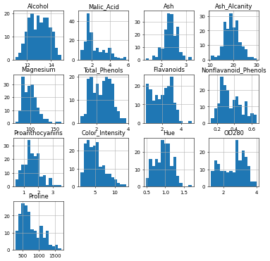

```python
wine.hist(figsize=(9,9),bins=15, layout=(4,4))
plt.savefig('histogram.png')
plt.show()
```

# Some More Exploration

```python
# How many NA elements in every column
wine.isnull().sum()
```

```
Alcohol                 0
Malic_Acid              0
Ash                     0
Ash_Alcanity            0
Magnesium               0
Total_Phenols           0
Flavanoids              0
Nonflavanoid_Phenols    0
Proanthocyanins         0
Color_Intensity         0
Hue                     0
OD280                   0
Proline                 0
dtype: int64
```

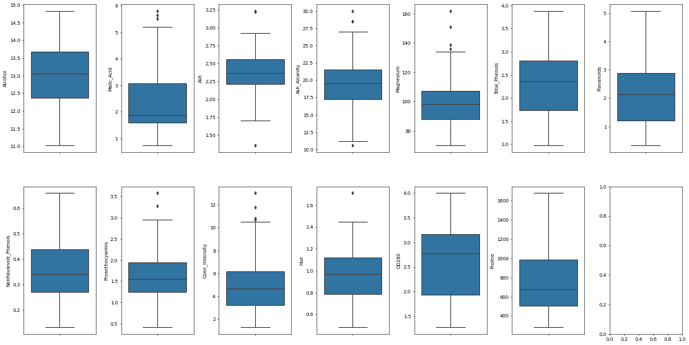

```python
# Box plots
fig,ax=plt.subplots(ncols=7,nrows=2, figsize=(20,10))
index=0
ax=ax.flatten()

for col,value in wine.items():
    sns.boxplot(y=col, data=wine,ax=ax[index])
    index+=1

plt.tight_layout(pad=0.6,w_pad=0.8,h_pad=6.5)
# Some outliers could be seen from the box plots(could be removed)
```

```python
import warnings
warnings.simplefilter(action='ignore', category=FutureWarning)
```

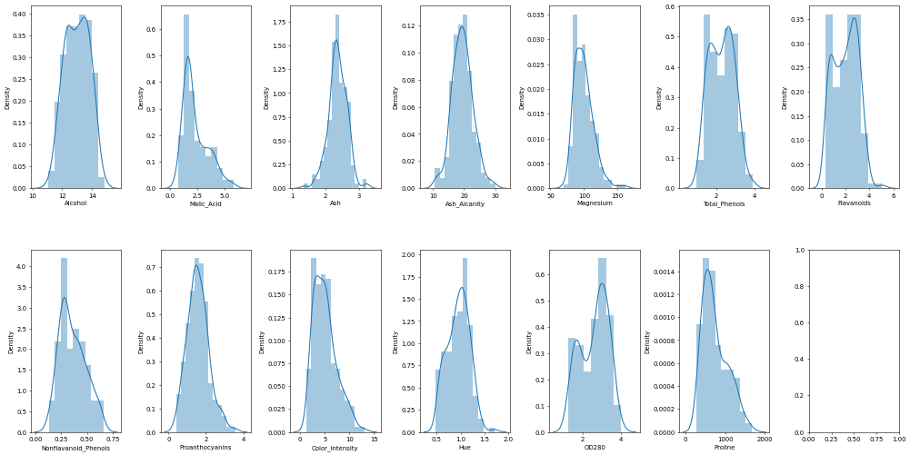

```python
# Create dist plot
fig,ax=plt.subplots(ncols=7,nrows=2, figsize=(20,10))
index=0
ax=ax.flatten()

for col,value in wine.items():
    sns.distplot(value,ax=ax[index])
    index+=1

plt.tight_layout(pad=0.6,w_pad=0.8,h_pad=6.5)
# Most of them are normal distribution
```

From the above boxplots and distribution graphs of the components, we can see that most of the variables have approximately normal distribution with a few outliers. Some components exhibit positive skewness, such as Malic_Acid, Magnesium, Nonflavanoid_Phenois, Color_Intensity and Proline. For kurtosis, most of the distributions are leptokurtic. Also, some components show bimodal distribution (have two peaks), such as Total_Phenois, Ravanoids and OD280.

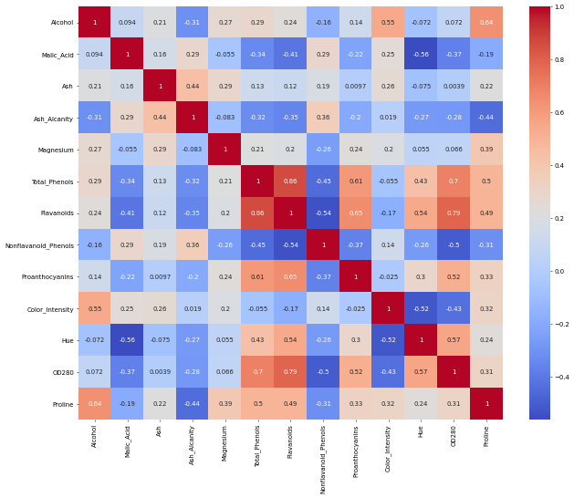

```python
# Coorelation matrix
corr=wine.corr()
plt.figure(figsize=(15,12))
sns.heatmap(corr,annot=True, cmap="coolwarm")
```

From the above correlation matrix, we can see that some of the components have high correlation among them, such as Ravanoids and Total_Phenois (a correlation of 0.86), Ravanoids and OD280 (a correlation of 0.79) as well as Total_Phenois and OD280 (a correlation of 0.7). For these 3 components, we might consider remove one or two of them in statistical analysis, since they may have multicollinearity issue.

# Now, try some machine learning

# kmeans & PCA

```python
# First, we need to import some useful packages of Kmeans and dimensionality.
from sklearn.cluster import KMeans
from sklearn.preprocessing import StandardScaler
from sklearn.decomposition import PCA

# In order to conduct the clustering process and further analysis, we should normalize the data first.
wine_scaled = StandardScaler().fit_transform(wine)
```

```python
# Create a list of SSE
sse = []
# We decide to try k from 1 to 10, to see which value is the best number of clusters.
for k in range(1,11):
    # Using kmeans method to fit the data and compute clustering.
    kmeans = KMeans(n_clusters = k)
    kmeans.fit(wine_scaled)
    sse.append(kmeans.inertia_)
sse
```

```
[2313.9999999999986,
 1659.0079672511504,
 1277.928488844643,
 1175.3518813658288,
 1111.0522296210818,
 1044.1158752011102,
 990.1778009882686,
 943.3305271002455,
 903.1061864963334,
 857.3933318793515]
```

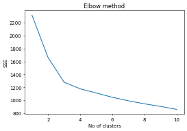

```python
# In this graph, using elbow method , it's obvious to see that 3 clusters is a good choice.

plt.plot(range(1,11), sse)
plt.title('Elbow method')
plt.xlabel('No of clusters')
plt.ylabel('SSE')
plt.show()
```

```python
# We consider "Customer_Segment" as the true value of clustering of wine.
y = f_in['Customer_Segment']
```

```python
# We import a package to train and to test the data.
from sklearn.model_selection import train_test_split

# At the moment, train set size will be 75% of the data and test size
wine_train,wine_test,y_train,y_test = train_test_split(wine,y,test_size=0.25,random_state=0,stratify=y)
# Results of the splitting are pandas dataframe and series.
wine_train.shape,wine_test.shape,y_train.shape,y_test.shape
```

```
((133, 13), (45, 13), (133,), (45,))
```

```python
# We need to normalize the train set and test set seperately.
wine_train = StandardScaler().fit_transform(wine_train)
wine_test = StandardScaler().fit_transform(wine_test)
X = np.concatenate((wine_train,wine_test),axis=0)
```

```python
from sklearn.cluster import KMeans
from sklearn.metrics import adjusted_rand_score

km = KMeans(n_clusters=3,init='k-means++',n_init=10,max_iter=300,tol=1e-04,random_state=0)

# Next we can fit our model on the training set, we have chosen kmeans model with 3 clusters and 300 iterations.
km.fit(wine_train)

# This is the predict value using kmeans method of clustering.
y_pred = km.predict(wine_test)
# Adjust_rand_score is a kind of way to calculate the accuracy of the model.
# The result shows that although there exists some errors, the accuracy of the model is pretty high.
print(adjusted_rand_score(y_test,y_pred))
```

```
0.926476731556521
```

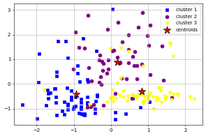

```python
km = KMeans(n_clusters=3, init='k-means++', n_init=10, max_iter=300, tol=1e-04, random_state=0)

y_km = km.fit_predict(X)

plt.scatter(X[y_km == 0, 0], X[y_km == 0, 1], s=50, c='blue', marker='s', label='cluster 1')
plt.scatter(X[y_km == 1, 0], X[y_km == 1, 1], s=50, c='purple', marker='o', label='cluster 2')
plt.scatter(X[y_km == 2, 0], X[y_km == 2, 1], s=50, c='yellow', marker='v', label='cluster 3')
plt.scatter(km.cluster_centers_[:, 0], km.cluster_centers_[:, 1], s=250, marker='*', c='red', edgecolor='black', label='centroids')
plt.legend(scatterpoints=1)
plt.grid()
plt.tight_layout()
plt.show()
# The picture below is the clustering result without reduction of dimension.
```

```python
# Then we need to do the Principal Component Analysis.

from sklearn.decomposition import PCA
import mglearn
```

```python
# Use the numpy.cov function, we computed the covariance matrix of the standardized training dataset.
cov_mat = np.cov(wine_train.T)
# Use the linalg.eig function, we can get a vector (eigen_vals) consisting of the eigenvalues and the corresponding eigenvectors.
eigen_vals, eigen_vecs = np.linalg.eig(cov_mat)

print('\nEigenvalues \n%s' % eigen_vals)
```

```
Eigenvalues
[4.78020531 2.413934   1.60264394 0.95937723 0.85091699 0.65730521
 0.52466846 0.35170478 0.30160286 0.10412565 0.20276634 0.16757739
 0.18165669]
```

```python
# We use the NumPy cumsum function to calculate the cumulative sum of explained variances.

tot = sum(eigen_vals)
var_exp = [(i / tot) for i in sorted(eigen_vals, reverse=True)]
cum_var_exp = np.cumsum(var_exp)
```

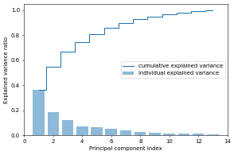

```python
# Then we can draw the the plot of the cumulative sum of explained variances.

import matplotlib.pyplot as plt

plt.bar(range(1, 14), var_exp, alpha=0.5, align='center', label='individual explained variance')
plt.step(range(1, 14), cum_var_exp, where='mid', label='cumulative explained variance')
plt.ylabel('Explained variance ratio')
plt.xlabel('Principal component index')
plt.legend(loc='best')
plt.tight_layout()
plt.show()
```

```python
# Keep the first seven principal components of the data, as they can explain more than 90% of the variance from the plot above.
# Then, we do not need to lost so much information after PCA.
pca = PCA(n_components=7)
# Fit the model to 'wine_scaled'.
pca.fit(wine_scaled)

wine_pca = pca.transform(wine_scaled)
print("Original shape: {}".format(str(wine_scaled.shape)))
print("Reduced shape: {}".format(str(wine_pca.shape)))
```

```
Original shape: (178, 13)
Reduced shape: (178, 7)
```

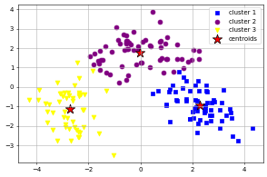

```python
# Use the Kmeans model and fit the data after PCA

y_km_pca = km.fit_predict(wine_pca)

# Draw the graph of kmeans result after dimensionality reduction.
plt.scatter(wine_pca[y_km_pca == 0, 0], wine_pca[y_km_pca == 0, 1], s=50, c='blue', marker='s', label='cluster 1')
plt.scatter(wine_pca[y_km_pca == 1, 0], wine_pca[y_km_pca == 1, 1], s=50, c='purple', marker='o', label='cluster 2')
plt.scatter(wine_pca[y_km_pca == 2, 0], wine_pca[y_km_pca == 2, 1], s=50, c='yellow', marker='v', label='cluster 3')
plt.scatter(km.cluster_centers_[:, 0], km.cluster_centers_[:, 1], s=250, marker='*', c='red', edgecolor='black', label='centroids')
plt.legend(scatterpoints=1)
plt.grid()
plt.tight_layout()
plt.show()
```

```python
pca = PCA(n_components=7)
pca.fit(wine_train)

wine_train_pca = pca.transform(wine_train)
print("Original shape: {}".format(str(wine_train.shape)))
print("Reduced shape: {}".format(str(wine_train_pca.shape)))
```

```
Original shape: (133, 13)
Reduced shape: (133, 7)
```

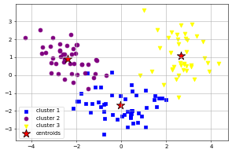

```python
# Use the Kmeans model and fit the train data after PCA

y_train_pca = km.fit_predict(wine_train_pca)

# Draw the graph of kmeans result after dimensionality reduction.
plt.scatter(wine_train_pca[y_train_pca == 0, 0], wine_train_pca[y_train_pca == 0, 1], s=50, c='blue', marker='s', label='cluster 1')
plt.scatter(wine_train_pca[y_train_pca == 1, 0], wine_train_pca[y_train_pca == 1, 1], s=50, c='purple', marker='o', label='cluster 2')
plt.scatter(wine_train_pca[y_train_pca == 2, 0], wine_train_pca[y_train_pca == 2, 1], s=50, c='yellow', marker='v', label='cluster 3')
plt.scatter(km.cluster_centers_[:, 0], km.cluster_centers_[:, 1], s=250, marker='*', c='red', edgecolor='black', label='centroids')
plt.legend(scatterpoints=1)
plt.grid()
plt.tight_layout()
plt.show()
```

Compares the plot above, we can see that after we use PCA, the plot can show the result of clustering in a more accurate way.

# Hierarchical Clustering

Hierarchical clustering is the cluster method that does not need to determine the number of clusters, because it is a bottom-up algorithm linking the elements from the minimal level and form the clusters step by step from bottom to up.

In detail, first, we treated each data point as single cluster. Hence, we will have 178 clusters at start. The number of data points will also be 178 at start. Then, we formed a big cluster by repeating to join two closet datapoints with centroid linkage. Finally, we got the two dendrograms.

```python
import scipy.cluster.hierarchy as shc
# Import function of cluster.hierarchy and set it as "shc"
from sklearn.cluster import AgglomerativeClustering
# Import the function of AgglomerativeClustering from library of sklearn
```

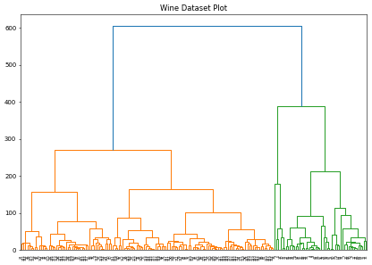

```python
plt.figure(figsize=(10, 7))
plt.title("Wine Dataset Plot")
dend = shc.dendrogram(shc.linkage(wine.iloc[:, [0, 1, 2, 3, 4, 5, 6, 7, 8, 9, 10, 11, 12]], method='centroid'))
# Firstly, we conducted Hierarchical Clustering with centroid linkage function on the original data set.
# Cluster distance as the point distance between the cluster means
```

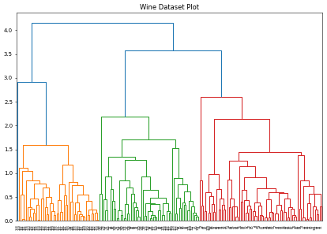

```python
plt.figure(figsize=(10, 7))
plt.title("Wine Dataset Plot")
dend = shc.dendrogram(shc.linkage(wine_pca, method='centroid'))
# Secondly, we conducted Hierarchical Clustering with centroid linkage function on the data set processed by PCA.
# Cluster distance as the point distance between the cluster means
```

```python
# We selected the second longest vertical distance in the first dendrogram, and there are three intersection points。
# So the number of clusters would be 3.
cluster_H = AgglomerativeClustering(n_clusters=3)

# Modelling the data
model_clt = cluster_H.fit(wine)
model_clt
# Print the array of pred1
pred1 = model_clt.labels_
pred1
```

```
array([0, 0, 0, 0, 2, 0, 0, 0, 0, 0, 0, 0, 0, 0, 0, 0, 0, 0, 0, 2, 2, 2,
       0, 0, 2, 2, 0, 0, 2, 0, 0, 0, 0, 0, 0, 2, 2, 0, 0, 2, 2, 0, 0, 2,
       2, 0, 0, 0, 0, 0, 0, 0, 0, 0, 0, 0, 0, 0, 0, 1, 2, 1, 2, 1, 1, 2,
       1, 1, 2, 2, 2, 1, 1, 0, 2, 1, 1, 1, 2, 1, 1, 2, 2, 1, 1, 1, 1, 1,
       2, 2, 1, 1, 1, 1, 1, 0, 2, 1, 2, 1, 2, 1, 1, 1, 2, 1, 1, 1, 1, 2,
       1, 1, 1, 1, 1, 1, 1, 1, 1, 1, 2, 1, 1, 1, 1, 1, 1, 1, 1, 1, 2, 1,
       1, 1, 2, 2, 2, 1, 1, 1, 1, 2, 1, 1, 2, 2, 1, 2, 2, 1, 1, 1, 1, 2,
       2, 2, 1, 2, 2, 2, 1, 2, 1, 2, 2, 1, 2, 2, 2, 2, 1, 1, 2, 2, 2, 2,
       2, 1], dtype=int64)
```

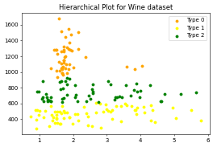

```python
plt.scatter(wine.iloc[:, [0, 1, 2, 3, 4, 5, 6, 7, 8, 9, 10, 11, 12]].values[pred1 == 0, 1], wine.iloc[:, [0, 1, 2, 3, 4, 5, 6, 7, 8, 9, 10, 11, 12]].values[pred1 == 0, 12], s = 20, c = 'orange', label = 'Type 0')
plt.scatter(wine.iloc[:, [0, 1, 2, 3, 4, 5, 6, 7, 8, 9, 10, 11, 12]].values[pred1 == 1, 1], wine.iloc[:, [0, 1, 2, 3, 4, 5, 6, 7, 8, 9, 10, 11, 12]].values[pred1 == 1, 12], s = 20, c = 'yellow', label = 'Type 1')
plt.scatter(wine.iloc[:, [0, 1, 2, 3, 4, 5, 6, 7, 8, 9, 10, 11, 12]].values[pred1 == 2, 1], wine.iloc[:, [0, 1, 2, 3, 4, 5, 6, 7, 8, 9, 10, 11, 12]].values[pred1 == 2, 12], s = 20, c = 'green', label = 'Type 2')
# Set up the color,size and lable for the scatter,which shows the new hierarchical clustering  with original wine data set.
plt.title('Hierarchical Plot for Wine dataset')
# Set up the title
plt.legend()
# Show the legend
```

# Silhouette

Besides elbow method, silhouette score is a more straightforward way to determine the number of clusters. Silhouette score is the mean silhouette coefficient of all samples.An example's silhouette coefficient is equal to (b-a)/max(a,b),where a is the mean distance to other samples in the same cluster and b is the mean intra-cluster distance.

```
<function matplotlib.pyplot.show(close=None, block=None)>
```

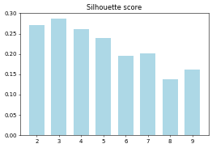

```python
from sklearn.metrics import silhouette_score

scores=[]
range_values=np.arange(2,10)
for i in range_values:
    kmeans=KMeans(init='k-means++',n_clusters=i,max_iter=300,n_init=10,random_state=0)
    kmeans.fit(X)
    score=silhouette_score(X,kmeans.labels_,metric='euclidean',sample_size=len(X))
    scores.append(score)
import matplotlib.pyplot as plt

# Now plot the bar chart for different clusters.

plt.figure()
plt.bar(range_values,scores,width=0.7,color="lightblue", align="center")
plt.title("Silhouette score")
plt.show

# The following graph shows the number of 3 has the best performance.
```

```python
# Let's create a list to show the specific silhouette scores from 2 to 9 clusters.

kmeans_per_k=[KMeans(n_clusters=k,random_state=0).fit(X)for k in range(1,10)]

silhouette_scores=[silhouette_score(X,model.labels_) for model in kmeans_per_k[1:]]
silhouette_scores

# 0.28626231 is the highest one.
```

```
[0.27005316153376846,
 0.28626231725790224,
 0.2615417739455801,
 0.24003369034529323,
 0.19561261718616435,
 0.2008754689873774,
 0.13715944749992934,
 0.162329557114378]
```

```python
from sklearn.metrics import silhouette_samples
from matplotlib.ticker import FixedLocator
from matplotlib import cm
```

[figure not shown]

```
avg: 0.28626231725790224
min: -0.026581835704785877
max: 0.5014749810553556
```

```python
# Silhouette diagram is a more intuitive way to show the silhouette coefficient for every samples. The silhouette coefficients are sorted by the their values in the group of the cluster number.

# First, we draw the silhouette diagram for 3 clusters.

km = KMeans(n_clusters=3,
            init='k-means++',
            n_init=10,
            max_iter=300,
            tol=1e-04,
            random_state=0)
y_km = km.fit_predict(X) # Use K-means devide the samples into 3 groups.

cluster_labels = np.unique(y_km)
n_clusters = cluster_labels.shape[0]
silhouette_vals = silhouette_samples(X, y_km, metric='euclidean')  # Return the silhouette coefficients for all samples

# Let's plot the silhouette diagram.

y_ax_lower, y_ax_upper = 0, 0
yticks = []
for i, c in enumerate(cluster_labels): # A loop to draw the silhouette coefficients for each cluster
    c_silhouette_vals = silhouette_vals[y_km == c]
    c_silhouette_vals.sort()
    y_ax_upper += len(c_silhouette_vals)
    color = cm.jet(float(i) / n_clusters)
    plt.barh(range(y_ax_lower, y_ax_upper), c_silhouette_vals, height=1.0,
             edgecolor='none', color=color)

    yticks.append((y_ax_lower + y_ax_upper) / 2.)
    y_ax_lower += len(c_silhouette_vals)

silhouette_avg = np.mean(silhouette_vals) # Use the dotted line to represent silhouette score
plt.axvline(silhouette_avg, color="red", linestyle="--")

plt.yticks(yticks, cluster_labels + 1)
plt.ylabel('Cluster')
plt.xlabel('Silhouette coefficient')

plt.tight_layout()
plt.show()
print('avg:',silhouette_avg)
print('min:',silhouette_vals.min())
print('max:',silhouette_vals.max())
```

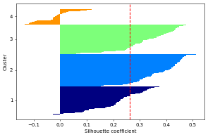

```
avg: 0.2615417739455801
min: -0.1333888725925001
max: 0.5116805486884449
```

```python
# The silhouette diagram for 4 clusters.

import numpy as np
from matplotlib import cm
from sklearn.metrics import silhouette_samples

km = KMeans(n_clusters=4,
            init='k-means++',
            n_init=10,
            max_iter=300,
            tol=1e-04,
            random_state=0)
y_km = km.fit_predict(X)

cluster_labels = np.unique(y_km)
n_clusters = cluster_labels.shape[0]
silhouette_vals = silhouette_samples(X, y_km, metric='euclidean')

y_ax_lower, y_ax_upper = 0, 0
yticks = []
for i, c in enumerate(cluster_labels):
    c_silhouette_vals = silhouette_vals[y_km == c]
    c_silhouette_vals.sort()
    y_ax_upper += len(c_silhouette_vals)
    color = cm.jet(float(i) / n_clusters)
    plt.barh(range(y_ax_lower, y_ax_upper), c_silhouette_vals, height=1.0,
             edgecolor='none', color=color)

    yticks.append((y_ax_lower + y_ax_upper) / 2.)
    y_ax_lower += len(c_silhouette_vals)

silhouette_avg = np.mean(silhouette_vals)
plt.axvline(silhouette_avg, color="red", linestyle="--")

plt.yticks(yticks, cluster_labels + 1)
plt.ylabel('Cluster')
plt.xlabel('Silhouette coefficient')

plt.tight_layout()
plt.show()
print('avg:',silhouette_avg)
print('min:',silhouette_vals.min())
print('max:',silhouette_vals.max())

# As the diagram shown, many samples in the cluster 4 are below 0, meaning that the samples are closer to other clusters and the mean silhouette coefficient is smaller than 3 cluster's. Therefore, dividing samples in 4 clusters is not the optimal method.
```

```python
# From the above analysis, we can conclude that the optimal clustering number is 3.
```

# Summary

In this project, we first make some descriptive analysis, drawing some plots, like the box plot and histogram to see whether there exists the outliers and how the data distribute. We also draw a correlation matrix to show the correlations between variables.

To cluster the type of the wine into group, we use two different ways, K-means clustering and Hierarchical clustering. In the K-means clustering, we notice that the value of "Proline" is much larger than the others, which means that "Proline" can play a much more important role and this may effect the outcome of clustering, so we do the normalization first. Then we choose SSE as the evaluation standard and determine the number of k as 3 by refering to the elbow plot. To present the result of K-means clustering more clearly, we choose PCA to reduce the dimension of wine data set. We calculate the eigenvalues of the data set, draw the plot of individual and cumulative explained variance, and choose to transform the original multiple variables into seven variables. With the work of PCA, we get a clear plot of K-means clustering result.

We also use PCA to reduce the dimension in the Hierarchical clustering, since there are 13 variables in this data set and high dimensionality may bring some trouble for clustering. It is obviously that with PCA we can cluster the data in our expected way. These two ways have their advantage and disavantage,but they all show a similar result——dividing the data into three categories.